# Segmentation of EU countries, based on consumer & business indicators

In this article i used a public Eurostat dataset, in order to develop a segmentation of the EU countries. This dataset consists of 5 confidence indicators:

- **Consumer Confidence Indicator**
- **Construction confidence indicator**
- **Industrial confidence indicator**
- **Retail confidence indicator**
- **Services Confidence Indicator**

These indicators are formed via qualitative surveys are conducted on a monthly basis in the following areas: **manufacturing industry, construction, consumers, retail trade, services and financial services**. These surveys started in 1980 and gradually include all the new EU members. About 137,000 firms and more than 41,000 consumers are currently surveyed every month across the EU.

The used metrics is the balance i.e. the difference between positive and negative answers (in percentage points of total answers), as index, as confidence indicators (arithmetic average of balances).

More information about these surveys can be found at this [link](https://ec.europa.eu/eurostat/cache/metadata/en/ei_bcs_esms.htm)

The eurozone consists of 19 countries: Austria, Belgium, Cyprus, Estonia, Finland, France, Germany, Greece, Ireland, Italy, Latvia, Lithuania, Luxembourg, Malta, the Netherlands, Portugal, Slovakia, Slovenia, and Spain.

The [Eurostat package](https://cran.r-project.org/web/packages/eurostat/index.html) used to obtain the original datasets.

More details about the ETL steps can be found, in the actual code, at the link at the end of the article.

# ETL & Exploratory Analysis

The original dataset consists of 11,340 observations that include these indicators in some countries for a specific month. For the analysis i only used data from 2014 onwards. In the processed dataset i used the median values of each variable in each country, so finally the dataset consists of 34 observations. One more variable was created, as the sum of all Business related confidence indicators (Construction, Industrial, Retail & Services Confidence Indicators), in order to have a genaral **business confidence indicator**.

It would be interesting to see the map plots of the confidence indicators. Below there are plots with the aggregated business & consumer indicators

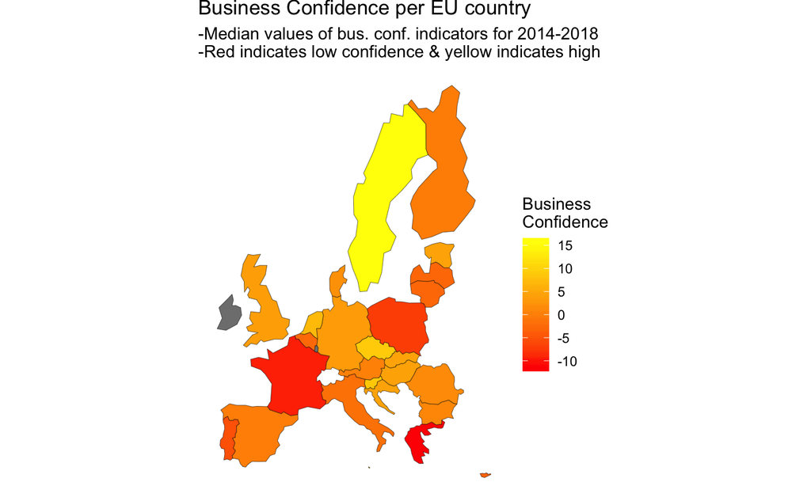

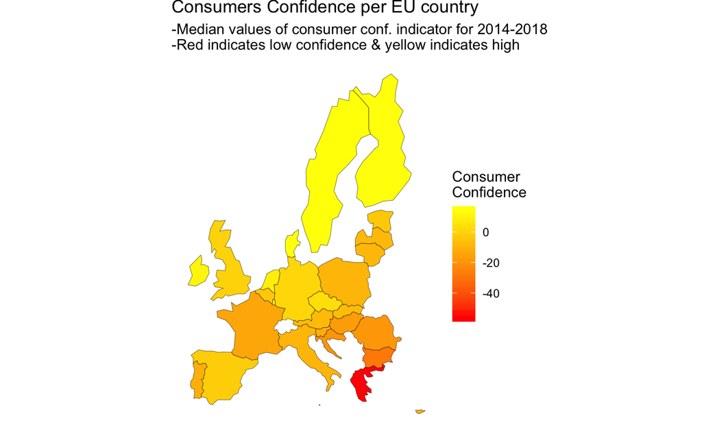

- It is clear that there are significant differences between countries.
- Again, Nothern Europe countries tend to have higher consumers confidence indicators.
- It seems that there are outlies here. Greece has significantly lower confidence indicator than the rest of the countries.

Below there is a scatterplot with marker labels indicating the positioning of each country in respect to consumer and confidence indicators. The overall business confidence indicator is the average of all business related features (Construction confidence indicator, Industrial confidence indicator, Retail confidence indicator & Services Confidence Indicator)

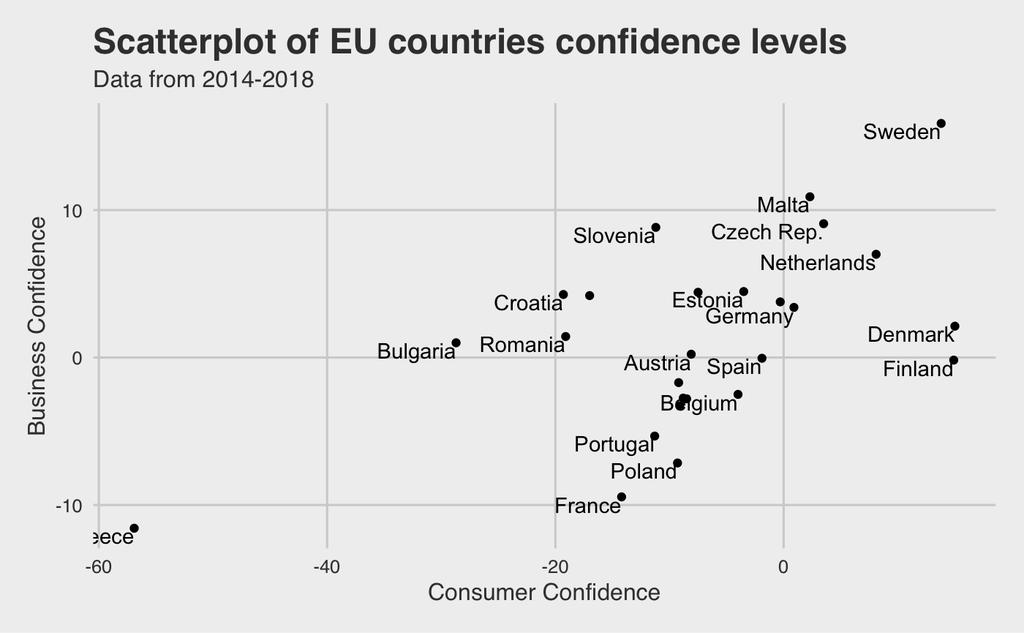

# Segmentation

There are quite a few differences between countries regarding confidence indicators. It would be very interesting to develop a segmentation, in order to check how well the countries are forming teams.  
The **k-means** algorithm used for the segmentation. It is the widest used unsupervised learning algorithm. The procedure follows a simple and easy way to classify a given data set through a certain number of clusters (assume k clusters) fixed apriori. The main idea is to define k centers, one for each cluster. These centers should be placed in a cunning way because of different location causes different result. So, the better choice is to place them as much as possible far away from each other. The next step is to take each point belonging to a given data set and associate it to the nearest center. When no point is pending, the first step is completed and an early group age is done. At this point we need to re-calculate k new centroids as barycenter of the clusters resulting from the previous step. After we have these k new centroids, a new binding has to be done between the same data set points and the nearest new center. A loop has been generated. As a result of this loop we may notice that the k centers change their location step by step until no more changes are done or in other words centers do not move any more.

## Indicate suitable number of clusters

The elbow (scree) plot below, is used to check for the suitable number of clusters. So what we are looking for, is the point at which the curve in the plot begins to flatten out.

In detail, the total within cluster sum of squares is calculated (the sum of euclidean distances between each observation and the centroid corresponding to the cluster to which the observation is assigned).

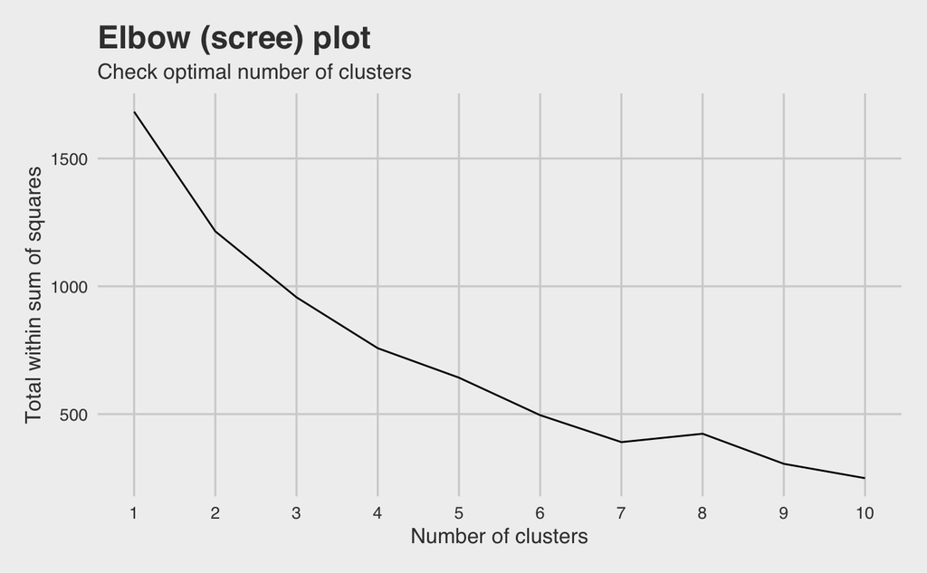

**Silhouette analysis**

In general, silhouette analysis determines how well each of the observations fit into corresponding cluster (Higher is better).

It involves calculating a measurement called the silhouette width for every observation:  
- A value close to 1 suggests that this observation is well matched to its current cluster.  
- A value of 0 suggests that it is on the border between two clusters and can possibly belong to either one.  
- A value close to -1 suggests that the observation has a better fit to its closest neighboring cluster.

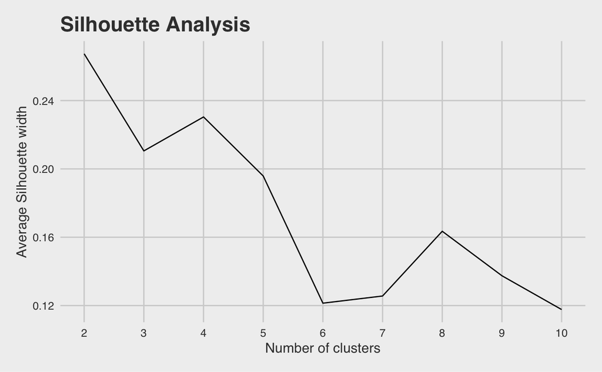

Although the silhouette value of the two clusters is the highest, four clusters were chosen for a few reasons:  
- It is close to the highest value  
- From the elbow plot, it seems that the curve is flatten out after cluster 4  
- Two clusters are very few to represent differences in EU countries

## Principal components

It would be nice to plot these clustering results and check these out visually. But it is impossible to visualise so many variables, as various dimensions are required. One way to overame this, is to use some dimensionality reduction technique. In particular, PCA (principal components analysis) is used.  
It finds structure in features and aid in visualization.  
In particular:  
- It will find linear combination of variables to create principal components (new features)  
- Maintain most variance in the data  
- Principal components (new features) are uncorrelated (i.e. orthogonal to each other)

The plot below (biplot) shows all the original observations plotted on the first 2 principal components.

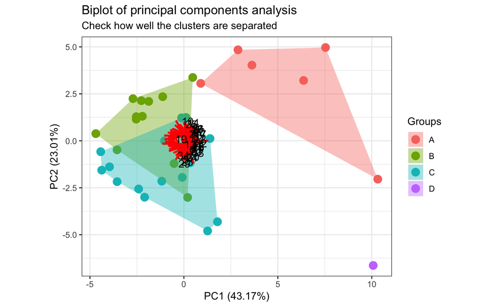

```r
pca_soft <- prcomp(scale(kmeans.dat))
library(ggord)
ggord(pca_soft, segment_countries$cluster, ellipse = FALSE, hull = TRUE, arrow = 1, vec_ext = 3, veccol = 'red', veclsz = 1) +
  labs(title = "Biplot of principal components analysis",
       subtitle = "Check how well the clusters are separated")
```

- The A cluster is clearly stands out from the rest of the clusters
- Clusters B & C are ovelapped to some extend
- Cluster D (Greece) is clearly stands out from the rest

It can be said, that clusters B & C could either considered as “close related” or even form a wider cluster since the differences are small.

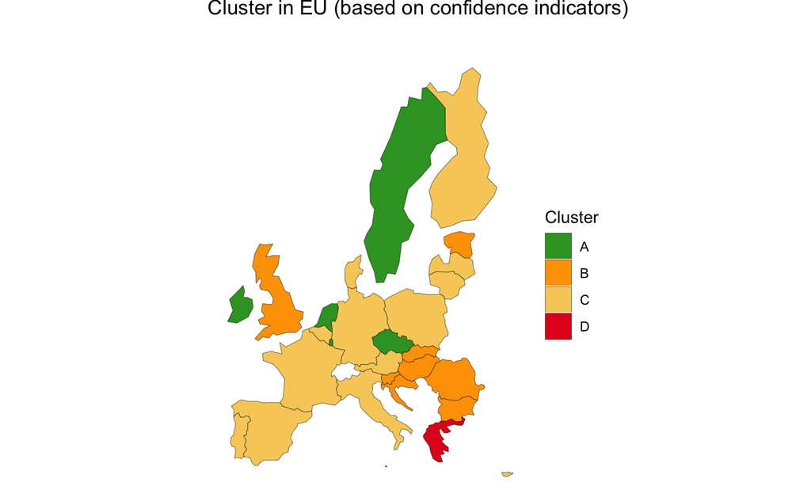

```r
# Create table with results
europeanUnionTable <- data.frame(country = segment_countries$geo, value = factor(segment_countries$cluster))
europeCoords$value <- europeanUnionTable$value[match(europeCoords$region,europeanUnionTable$country)]
# Plot the map
ggplot() +
  geom_polygon(data = europeCoords, aes(x = long, y = lat, group = region, fill = value),
                             colour = "black", size = 0.1) +
  coord_map(xlim = c(-13, 35),  ylim = c(32, 71))+
  theme(
  axis.text.x = element_blank(),
  axis.text.y = element_blank(), axis.ticks.x = element_blank(),
  axis.ticks.y = element_blank(), axis.title = element_blank(),
  plot.margin = unit(0 * c(-1.5, -1.5, -1.5, -1.5), "lines")) +
  labs(title = "Cluster in EU (based on confidence indicators)",
       subtitle = "",
       fill = "Cluster")+
  theme(panel.grid = element_blank(),
        axis.text = element_blank(),
        axis.ticks = element_blank(),
        panel.background = element_blank()) +
   scale_fill_manual(values=c("#33A02C", "#FFA100", "#F7CE68", "#E31A1C"))
```